# p8105_hw5_my2644

ymysherry

11/18/2020

```r
knitr::opts_chunk$set(
  fig.width = 6,
  fid.asp = .6,
  out.width = "90%"
)

theme_set(theme_minimal() + theme(legend.position = "bottom"))

options(
  ggplot2.continuous.colour = "viridis",
  ggplot2.continuous.fill = "viridis"
)

scale_colour_discrete = scale_color_viridis_d
scale_fill_discrete = scale_fill_viridis_d
```

## Problem 1

Read in data. Create a city_state variable (e.g. “Baltimore, MD”) and then summarize within cities to obtain the total number of homicides and the number of unsolved homicides (those for which the disposition is “Closed without arrest” or “Open/No arrest”).

```r
homicide_df =
  read_csv("hom_data/homicide-data.csv") %>%
  mutate(
    city_state = str_c(city, state, sep = "_"),

    resolved = case_when(
      disposition == "Closed without arrest" ~ "unsolved",
      disposition == "Open/No arrest" ~ "unsolved",
      disposition == "Closed by arrest" ~ "solved"
    )
  ) %>%

select(city_state, resolved) %>%
  filter(city_state != "Tulsa_AL")
```

summarize the dataset

```r
aggregate_df =
homicide_df %>%
  group_by(city_state) %>%
  summarize(
    hom_total = n(),
    hom_unsolved = sum(resolved == "unsolved")
  )
```

For the city of Baltimore, MD, use the prop.test function to estimate the proportion of homicides that are unsolved; save the output of prop.test as an R object, apply the broom::tidy to this object and pull the estimated proportion and confidence intervals from the resulting tidy dataframe.

```r
prop.test(
  aggregate_df %>% filter(city_state =="Baltimore_MD") %>% pull(hom_unsolved),
   aggregate_df %>% filter(city_state =="Baltimore_MD") %>% pull(hom_total)) %>%

  broom::tidy()
```

```
## # A tibble: 1 x 8
##   estimate statistic  p.value parameter conf.low conf.high method    alternative
##      <dbl>     <dbl>    <dbl>     <int>    <dbl>     <dbl> <chr>     <chr>
## 1    0.646      239. 6.46e-54         1    0.628     0.663 1-sample… two.sided
```

Now run prop.test for each of the cities in your dataset, and extract both the proportion of unsolved homicides and the confidence interval for each. Do this within a “tidy” pipeline, making use of purrr::map, purrr::map2, list columns and unnest as necessary to create a tidy dataframe with estimated proportions and CIs for each city.

```r
results_df =
aggregate_df %>%
  mutate(
    prop_tests= map2(.x = hom_unsolved, .y = hom_total, ~prop.test(x = .x, n = .y)),
    tidy_tests = map(.x = prop_tests, ~broom::tidy(.x))
  ) %>%
  select(-prop_tests) %>%
  unnest(tidy_tests) %>%
  select(city_state, estimate, conf.low, conf.high)
```

Create a plot that shows the estimates and CIs for each city – check out geom_errorbar for a way to add error bars based on the upper and lower limits. Organize cities according to the proportion of unsolved homicides.

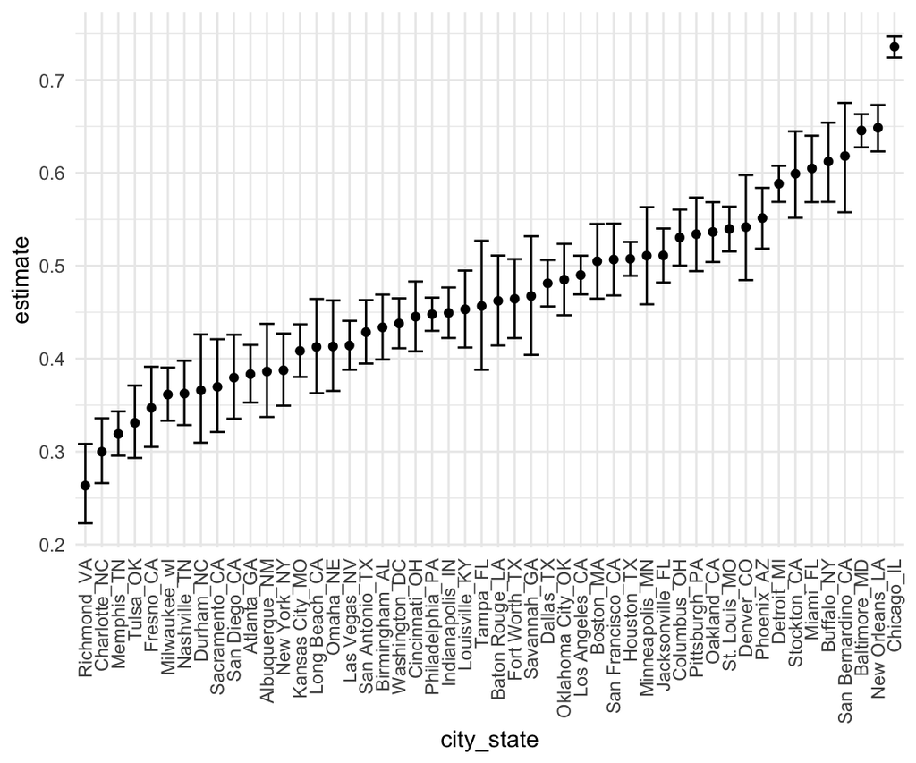

```r
results_df %>%
  mutate(city_state = fct_reorder(city_state, estimate)) %>%
  ggplot(aes(x = city_state, y = estimate)) +
  geom_point() +
  geom_errorbar(aes(ymin = conf.low, ymax = conf.high)) +
  theme(axis.text.x = element_text(angle = 90, vjust = 0.5, hjust = 1))
```

##Problem 2 Create a tidy dataframe containing data from all participants, including the subject ID, arm, and observations over time:

Iterate over file names and read in data for each subject using purrr::map and saving the result as a new variable in the dataframe

Tidy the result; manipulate file names to include control arm and subject ID, make sure weekly observations are “tidy”, and do any other tidying that’s necessary

```r
lda_df =
  tibble(
    path = list.files("lda_data")) %>%
  mutate(
    data = map(.x = str_c("lda_data/", path), ~read_csv(.x))
  ) %>%
   unnest(data) %>%
  mutate(
    path = substr(path, 0, 6),
    exp_arm = substr(path, 0, 3),
    subject_id = substr(path, 5, 6)) %>%

  select(path, exp_arm, subject_id, week_1:week_8) %>%
  pivot_longer(
    week_1:week_8,
    names_to = "week",
    values_to = "observation"
  ) %>%
  mutate(week = substr(week, 6, 7))
```

Make a spaghetti plot showing observations on each subject over time, and comment on differences between groups.

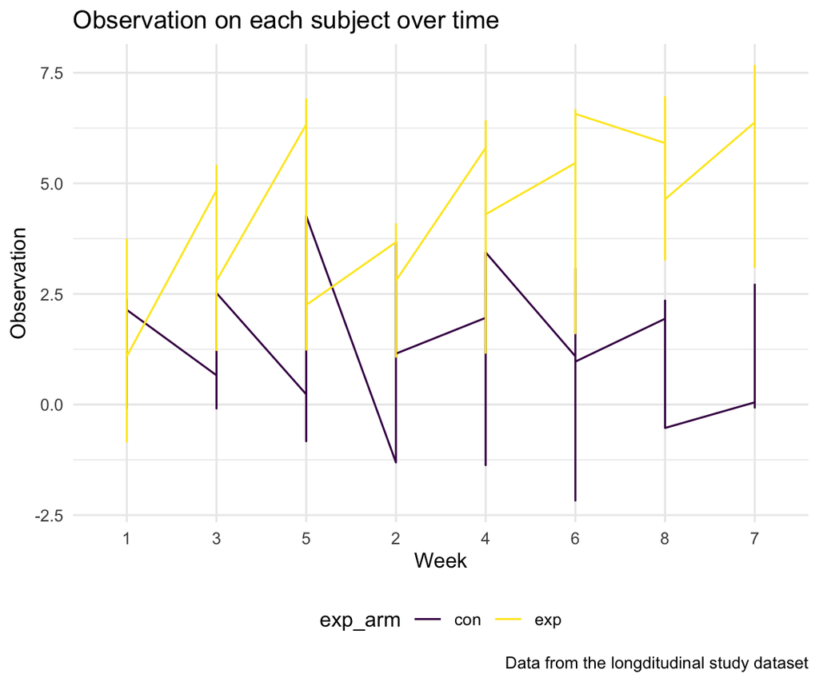

```r
lda_df %>%
  mutate(week = fct_reorder(week, observation)) %>%
  ggplot(aes(x = week, y = observation, group = exp_arm)) +
  geom_line(aes(color = exp_arm)) +
  labs(
  title = "Observation on each subject over time",
  x = "Week",
  y = "Observation",
  caption = "Data from the longditudinal study dataset"
  )
```

The spaghetti plot shows that over time, the subjects inexperimental arm have higher observed values than subjects in the control arm.

##Problem 3 set the following design elements: Fix n=30 Fix σ=5 Set μ=0. For each dataset, save μ̂ and the p-value arising from a test of H:μ=0 using α=0.05. Hint: to obtain the estimate and p-value, use broom::tidy to clean the output of t.test.

```r
sim_mean_sd = function(n = 30, mu = 0, sigma = 5) {
  sim_data = tibble(
    x = rnorm(n, mean = mu, sd = sigma)
  ) %>%

  t.test(alternative = "two.sided", mu = 0) %>%
  broom::tidy() %>%
  select(estimate, p.value)
}
```

Generate 5000 datasets from the modelwith simulation function

```r
sim_results = function(x) {
  rerun(5000, sim_mean_sd(mu = x)) %>%
  bind_rows()
}
sim_results(0)
```

```
## # A tibble: 5,000 x 2
##    estimate p.value
##       <dbl>   <dbl>
##  1  -0.740   0.491
##  2  -1.49    0.141
##  3  -1.59    0.0865
##  4  -0.269   0.787
##  5   1.25    0.174
##  6  -0.0492  0.958
##  7  -1.32    0.178
##  8   0.911   0.354
##  9   1.15    0.262
## 10  -0.369   0.692
## # … with 4,990 more rows
```

Repeat the above for μ={1,2,3,4,5,6} map to all mu and create a table calculate proportion of null rejected and estimated value for each mu

```r
 list_df =
  tibble(mu = 0:6,
         t_test = map(.x = mu, ~sim_results(.x))
  )

summarize_fx = function(x){
  x %>%
    mutate(
      H0 = case_when(
        p.value < 0.05 ~ "rejected",
        p.value > 0.05 ~ "not rejected"
        )
    ) %>%
    summarize(
      null_reject = sum(H0 == "rejected"),
      prop = null_reject/5000,
      avg_est = mean(estimate)
  )
}

list_df_test = list_df %>%
   mutate(
    summarize_list = map(.x = t_test, ~summarize_fx(.x))
  ) %>%
  unnest(summarize_list)
```

Make a plot showing the proportion of times the null was rejected (the power of the test) on the y axis and the true value of μ on the x axis. Describe the association between effect size and power.

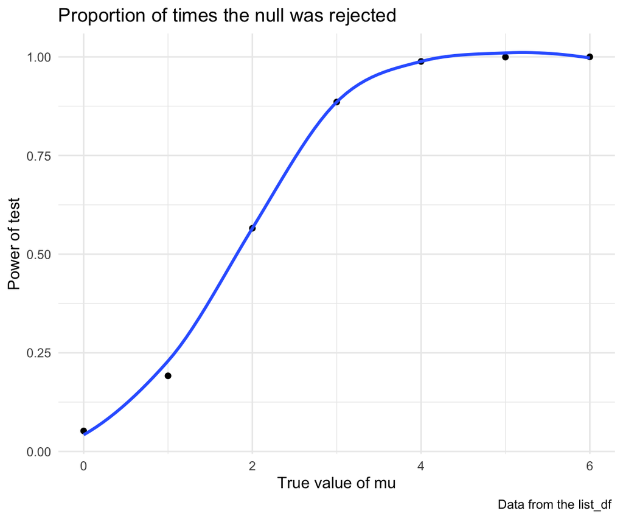

```r
list_df_test %>%
  ggplot(aes(x = mu, y = prop)) +
  geom_point() +
  geom_smooth(se = FALSE) +
  labs(
  title = "Proportion of times the null was rejected",
  x = "True value of mu",
  y = "Power of test",
  caption = "Data from the list_df "
  )
```

When the effect size grows, the power of test increases at an increasing speed and then at a decreasing speed

Make a plot showing the average estimate of μ̂ on the y axis and the true value of μ on the x axis.

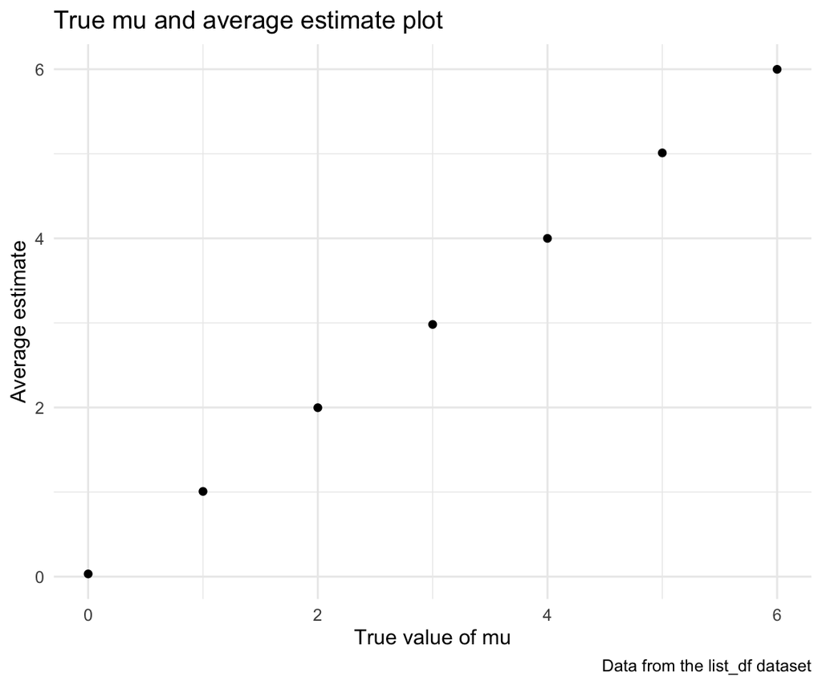

```r
list_df_test %>%
  ggplot(aes(x = mu, y = avg_est)) +
  geom_point() +
  labs(
  title = "True mu and average estimate plot",
  x = "True value of mu",
  y = "Average estimate",
  caption = "Data from the list_df dataset"
  )
```

Make a second plot (or overlay on the first) the average estimate of μ̂ only in samples for which the null was rejected on the y axis and the true value of μ on the x axis.

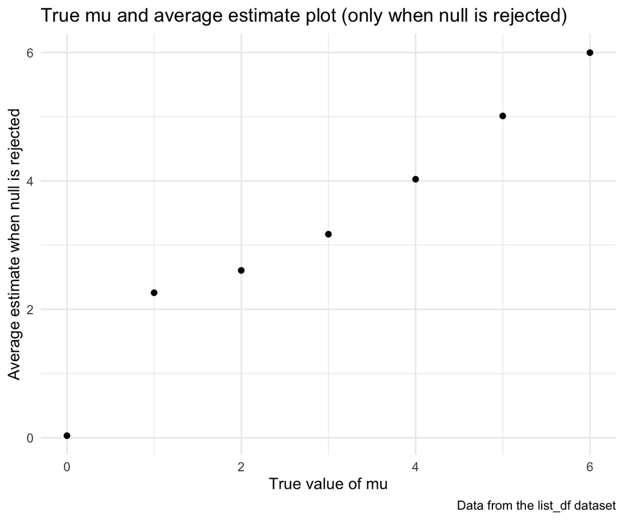

```r
reject_fx = function(x){
   x %>%
    mutate(
      H0 = case_when(
        p.value < 0.05 ~ "rejected",
        p.value > 0.05 ~ "not rejected"
        )
    ) %>%
    filter(H0 == "rejected") %>%
    summarize(avg_est_rej = mean(estimate))
}
list_df %>%
  mutate(
    avg_list = map(.x = list_df$t_test, ~reject_fx(.x))
  ) %>%
  unnest(avg_list) %>%
  ggplot(aes(x = mu, y = avg_est_rej)) +
  geom_point() +
  labs(
  title = "True mu and average estimate plot (only when null is rejected)",
  x = "True value of mu",
  y = "Average estimate when null is rejected",
  caption = "Data from the list_df dataset"
  )
```

Is the sample average of μ̂ across tests for which the null is rejected approximately equal to the true value of μ? Why or why not?

The sample average of mu across tests for which null is rejected is not equal to the true valye of mu, in partucularly when effect size is smaller. When the sample size is not large enough, the difference between sample mean and true mu gets bigger.